# ShinyApp Project - Central Limit Theorem

August 27, 2019

## Simulation of Central Limit Theorem

The theorem simply states that the arithmetic means of a group of observations, drawn from any distribution with finite mean and variance, approximately follows a *normal* distribution given that the number of observations is large enough.

The simulation of the theorem consists of:

- Drawing a sample of a given size from any distribtuion and then computing the mean of the sample
- Repeating the above step for a given number of repetitions and then plotting the histogram of computed means

As the sample size increases, the histogram should look like a normal distribution.

## Parent Distribution

- In the App, the user has two options for the parent distribution, exponential or uniform:

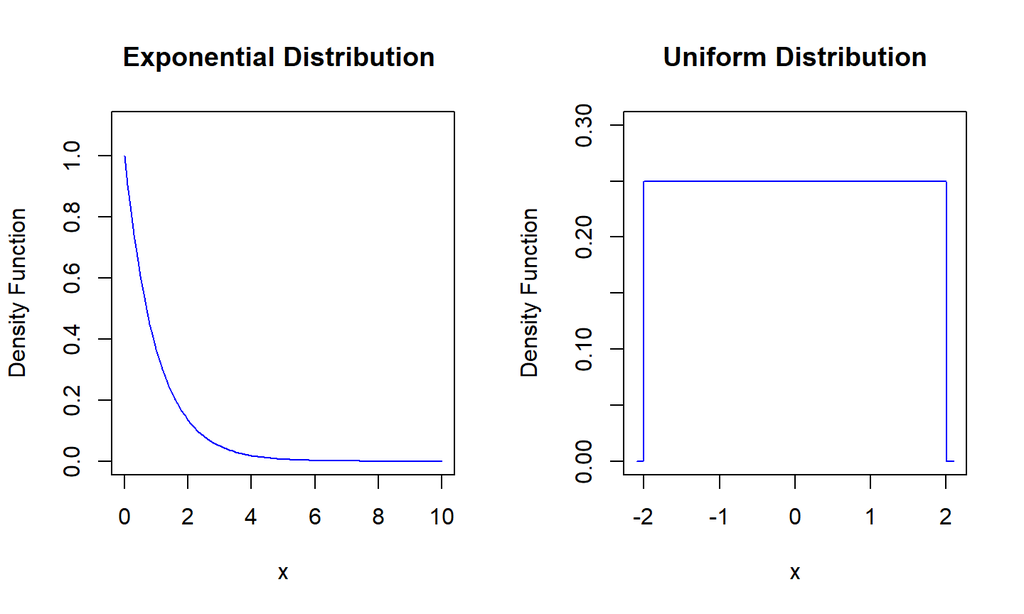

- Each distribution has its own parameter:

  | Distribution | Parameter |
  | --- | --- |
  | Exponential | Rate |
  | Unifrom | Range |

## Sample Size and Number of Repetitions

After choosing the parent distribution with its parameter, the user has to specify the following:

- Sample Size: number of observations to be drawn
- Number of Repetitions: number of repeated experiments, at the end of which, the histogram of sample means will be plotted

## Example

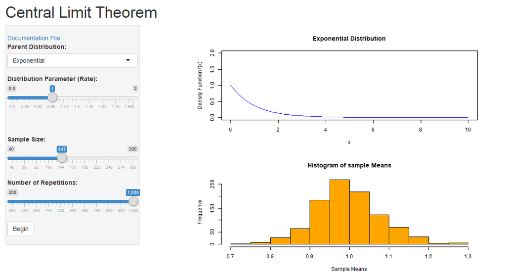